# Saturated Hydraulic Conductivity in the Dillon Creek and Hall Creek Watersheds

John Hammerly

2019-05-03

# Study Area

The study area of interest includes 2 similar watershed areas in southern Indiana. Observations and measurements were taken in the Dillon Creek watershed where a model was developed. Hall Creek watershed is where the model was applied. The extents of the watersheds mapped below, show the Dillon Creek Watershed matches the HUC12 unit. The Hall Creek Watershed were the model was applied is a subset of the HUC12 Hall Creek Watershed.

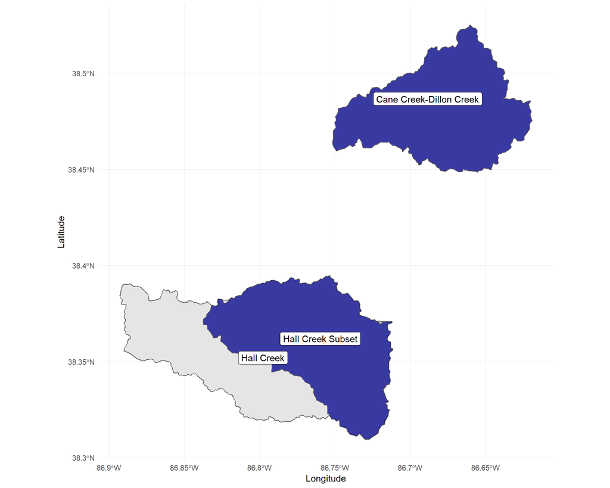

# Dillon Creek

Amoozemeter measurements were collected in pasture and forest catchments. Sites and pedons are in NASIS. Amoozemeter measurements are not. Adding them would require a permission change to Region 11, or a willing data entry staff member from Region 6.

## Catchment Locations

The forest catchment is located just outside the watershed.

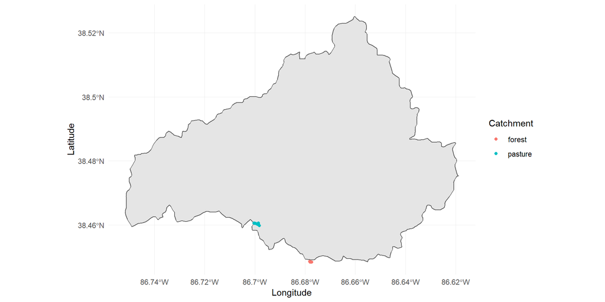

## Pasture Catchment

### NASIS Pedon Profiles

These pedons have correlated taxonomic classifications.

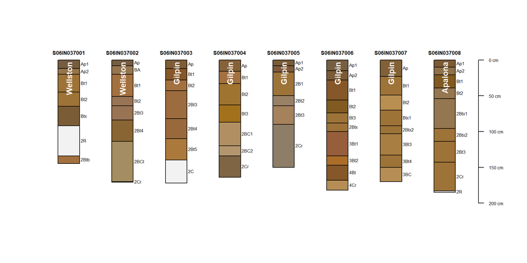

### NASIS Pedon Locations

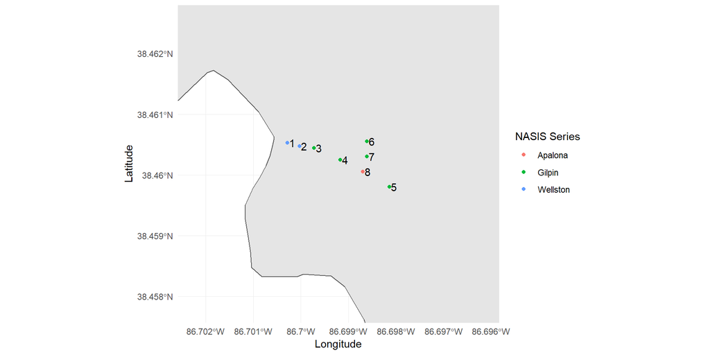

### Amoozemeter Ksat Data

Measurement data includes a mean ksat and standard deviation for each of the 5 repetitions at each site. Comparing the series in the table below to the NASIS pedons, you can see discrepancies. Revisiting the classification of these soils and updating in NASIS and this table is needed. The table below is a cleaned version of the summary of raw data.

| site_id | layer | horizon | dept | depb | um_ksat | taxonname | ssurgo_taxonname | taxon_class | position | catchment |
| --- | --- | --- | --- | --- | --- | --- | --- | --- | --- | --- |
| S06IN037001 | 1 | Ap | 0 | 17 | 1.3204 | Zanesville | Gilpin | Fine-loamy, mixed, active, mesic Typic Hapludults | summit | pasture |
| S06IN037001 | 2 | Bt1 | 17 | 40 | 1.6782 | Zanesville | Gilpin | Fine-loamy, mixed, active, mesic Typic Hapludults | summit | pasture |
| S06IN037001 | 4 | Btx | 40 | 80 | 1.2123 | Zanesville | Gilpin | Fine-loamy, mixed, active, mesic Typic Hapludults | summit | pasture |
| S06IN037002 | 2 | BA | 0 | 20 | 0.9092 | Deuchars | Gilpin | Fine-loamy, mixed, active, mesic Typic Hapludults | summit | pasture |
| S06IN037002 | 3 | Bt1 | 20 | 40 | 0.1128 | Deuchars | Gilpin | Fine-loamy, mixed, active, mesic Typic Hapludults | summit | pasture |
| S06IN037002 | 6 | 2Bt4 | 40 | 110 | 0.1267 | Deuchars | Gilpin | Fine-loamy, mixed, active, mesic Typic Hapludults | summit | pasture |
| S06IN037003 | 1 | Ap | 0 | 16 | 23.0638 | Deuchars | Gilpin | Fine-loamy, mixed, active, mesic Typic Hapludults | shoulder | pasture |
| S06IN037003 | 2 | Bt1 | 16 | 40 | 0.6048 | Deuchars | Gilpin | Fine-loamy, mixed, active, mesic Typic Hapludults | shoulder | pasture |
| S06IN037003 | 4 | 2Bt3 | 40 | 71 | 0.0583 | Deuchars | Gilpin | Fine-loamy, mixed, active, mesic Typic Hapludults | shoulder | pasture |
| S06IN037004 | 1 | Ap | 0 | 16 | 35.8026 | Deuchars | Gilpin | Fine-loamy, mixed, active, mesic Typic Hapludults | sideslope | pasture |
| S06IN037004 | 2 | Bt1 | 16 | 32 | 0.2534 | Deuchars | Gilpin | Fine-loamy, mixed, active, mesic Typic Hapludults | sideslope | pasture |
| S06IN037004 | 3 | Bt3 | 32 | 80 | 0.0728 | Deuchars | Gilpin | Fine-loamy, mixed, active, mesic Typic Hapludults | sideslope | pasture |
| S06IN037005 | 1 | Ap | 0 | 16 | 1.5337 | Inclusion | Wellston | Fine-silty, mixed, active, mesic Ultic Hapludalfs | toeslope | pasture |
| S06IN037005 | 3 | 2Bt1 | 16 | 40 | 1.4704 | Inclusion | Wellston | Fine-silty, mixed, active, mesic Ultic Hapludalfs | toeslope | pasture |
| S06IN037006 | 1 | Ap | 0 | 17 | 0.8776 | Apalona | Wellston | Fine-silty, mixed, active, mesic Ultic Hapludalfs | shoulder | pasture |
| S06IN037006 | 3 | Bt1 | 17 | 45 | 1.1209 | Apalona | Wellston | Fine-silty, mixed, active, mesic Ultic Hapludalfs | shoulder | pasture |
| S06IN037006 | 6 | 2Btx | 45 | 95 | 0.1145 | Apalona | Wellston | Fine-silty, mixed, active, mesic Ultic Hapludalfs | shoulder | pasture |
| S06IN037006 | 7 | 3Bt1 | 95 | 125 | 0.0267 | Apalona | Wellston | Fine-silty, mixed, active, mesic Ultic Hapludalfs | shoulder | pasture |
| S06IN037007 | 1 | Ap | 0 | 17 | 1.7399 | Apalona | Gilpin | Fine-loamy, mixed, active, mesic Typic Hapludults | shoulder | pasture |
| S06IN037007 | 2 | Bt1 | 17 | 40 | 1.2959 | Apalona | Gilpin | Fine-loamy, mixed, active, mesic Typic Hapludults | shoulder | pasture |
| S06IN037007 | 4 | Btx1 | 40 | 90 | 0.0986 | Apalona | Gilpin | Fine-loamy, mixed, active, mesic Typic Hapludults | shoulder | pasture |
| S06IN037008 | 1 | Ap | 0 | 17 | 1.9943 | Apalona | Gilpin | Fine-loamy, mixed, active, mesic Typic Hapludults | sideslope | pasture |
| S06IN037008 | 3 | Bt1 | 17 | 37 | 1.5662 | Apalona | Gilpin | Fine-loamy, mixed, active, mesic Typic Hapludults | sideslope | pasture |
| S06IN037008 | 5 | 2Btx1 | 37 | 75 | 0.2750 | Apalona | Gilpin | Fine-loamy, mixed, active, mesic Typic Hapludults | sideslope | pasture |

### Amoozemeter Ksat Plots

Not all soil layers described had ksat measurements taken. The plots below are of only the measured horizons.

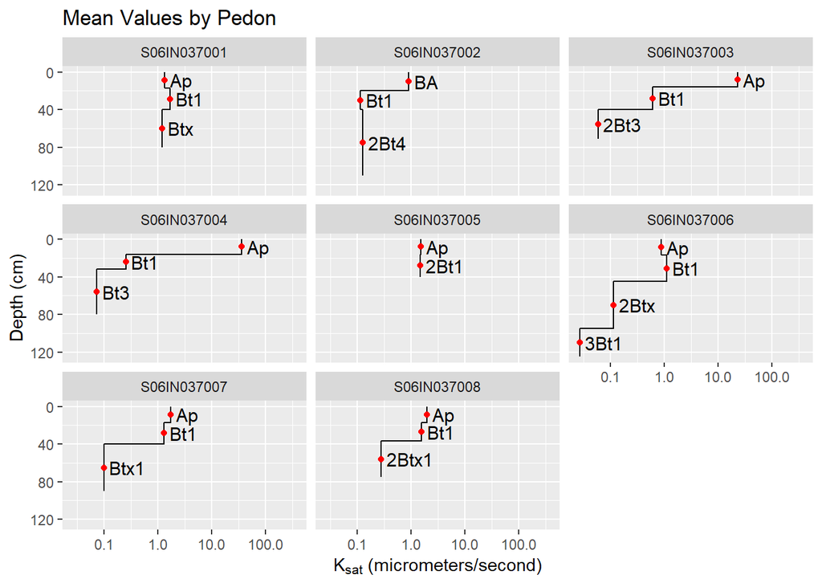

## Forest Catchment

### NASIS Pedon Profiles

These pedons taxonomic classification is still “sampled as”, and should be updated.

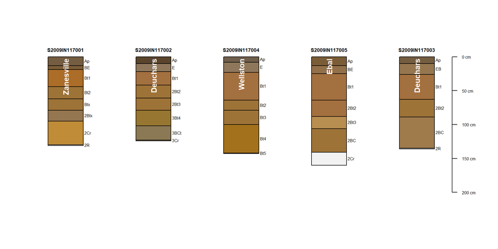

### NASIS Pedon Locations

These measurements were taken just beyond the boundary of the watershed.

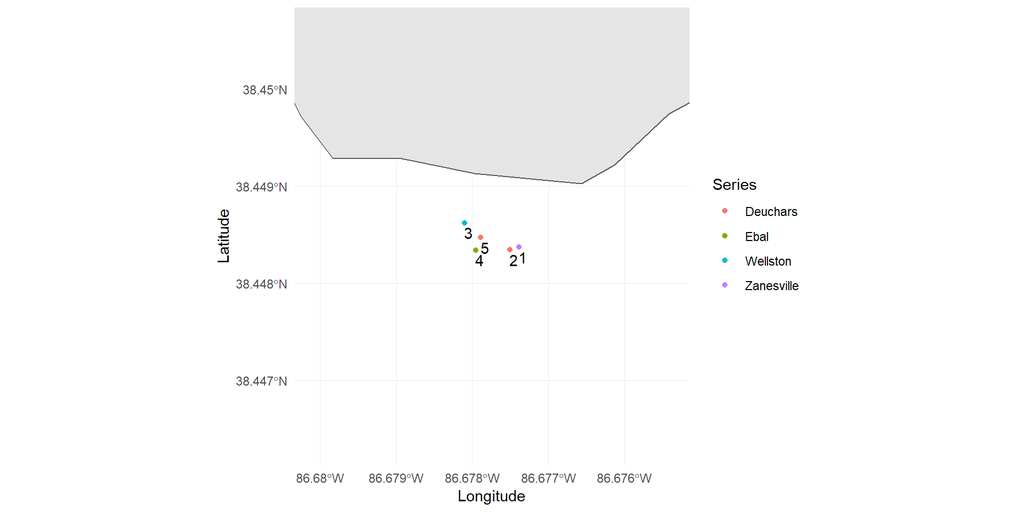

### Amoozemeter Ksat Data

| site_id | layer | horizon | dept | depb | um_ksat | taxonname | ssurgo_taxonname | taxon_class | position | catchment |
| --- | --- | --- | --- | --- | --- | --- | --- | --- | --- | --- |
| S09IN117001 | 1 | Ap | 0 | 18 | 1.4890 | Zanesville tax adj | Wellston-Ebal-Adyeville complex | fine-silty, mixed, active, mesic Oxiaquic Fragiudalfs | summit | forest |
| S09IN117001 | 2 | Bt | 18 | 43 | 0.2217 | Zanesville tax adj | Wellston-Ebal-Adyeville complex | fine-silty, mixed, active, mesic Oxiaquic Fragiudalfs | summit | forest |
| S09IN117001 | 3 | 2Bt1x | 43 | 89 | 0.2534 | Zanesville tax adj | Wellston-Ebal-Adyeville complex | fine-silty, mixed, active, mesic Oxiaquic Fragiudalfs | summit | forest |
| S09IN117001 | 4 | 2Cr | 89 | 100 | 0.1050 | Zanesville tax adj | Wellston-Ebal-Adyeville complex | fine-silty, mixed, active, mesic Oxiaquic Fragiudalfs | summit | forest |
| S09IN117002 | 1 | Ap/E | 0 | 18 | 5.4227 | Deuchars tax adj | Wellston-Adyeville-Ebal | fine-loamy over clayey, mixed, active, mesic Oxyaquic Hapludalfs | shoulder | forest |
| S09IN117002 | 2 | 2Bt | 18 | 68 | 0.3384 | Deuchars tax adj | Wellston-Adyeville-Ebal | fine-loamy over clayey, mixed, active, mesic Oxyaquic Hapludalfs | shoulder | forest |
| S09IN117002 | 3 | 3Bt4 | 68 | 103 | 0.0264 | Deuchars tax adj | Wellston-Adyeville-Ebal | fine-loamy over clayey, mixed, active, mesic Oxyaquic Hapludalfs | shoulder | forest |
| S09IN117002 | 4 | 3Cr | 103 | 152 | 0.0469 | Deuchars tax adj | Wellston-Adyeville-Ebal | fine-loamy over clayey, mixed, active, mesic Oxyaquic Hapludalfs | shoulder | forest |
| S09IN117003 | 1 | Ap/EB | 0 | 19 | 8.9099 | Deuchars | Wellston-Adyeville-Ebal | fine-loamy over clayey, mixed, active, mesic Oxyaquic Hapludalfs | shoulder | forest |
| S09IN117003 | 2 | Bt1 | 19 | 46 | 0.4573 | Deuchars | Wellston-Adyeville-Ebal | fine-loamy over clayey, mixed, active, mesic Oxyaquic Hapludalfs | shoulder | forest |
| S09IN117003 | 3 | 2Bc | 46 | 71 | 0.0367 | Deuchars | Wellston-Adyeville-Ebal | fine-loamy over clayey, mixed, active, mesic Oxyaquic Hapludalfs | shoulder | forest |
| S09IN117004 | 1 | Ap/E | 0 | 25 | 0.4603 | Wellston tax adj | Wellston-Adyeville-Ebal | fine-loamy, mixed, active, mesic Ultic Hapludalfs | sideslope | forest |
| S09IN117004 | 2 | Bt1 | 25 | 47 | 0.2534 | Wellston tax adj | Wellston-Adyeville-Ebal | fine-loamy, mixed, active, mesic Ultic Hapludalfs | sideslope | forest |
| S09IN117004 | 3 | Bt3 | 47 | 94 | 0.0642 | Wellston tax adj | Wellston-Adyeville-Ebal | fine-loamy, mixed, active, mesic Ultic Hapludalfs | sideslope | forest |
| S09IN117005 | 1 | A/BE | 0 | 16 | 3.5897 | Ebal | Wellston-Adyeville-Ebal | fine-silty, mixed, active, mesic Oxyaquic Hapludalfs | toeslope | forest |
| S09IN117005 | 2 | Bt1 | 16 | 50 | 0.6670 | Ebal | Wellston-Adyeville-Ebal | fine-silty, mixed, active, mesic Oxyaquic Hapludalfs | toeslope | forest |
| S09IN117005 | 3 | 2Bt3 | 50 | 107 | 0.0692 | Ebal | Wellston-Adyeville-Ebal | fine-silty, mixed, active, mesic Oxyaquic Hapludalfs | toeslope | forest |

### Amoozemeter Ksat Plots

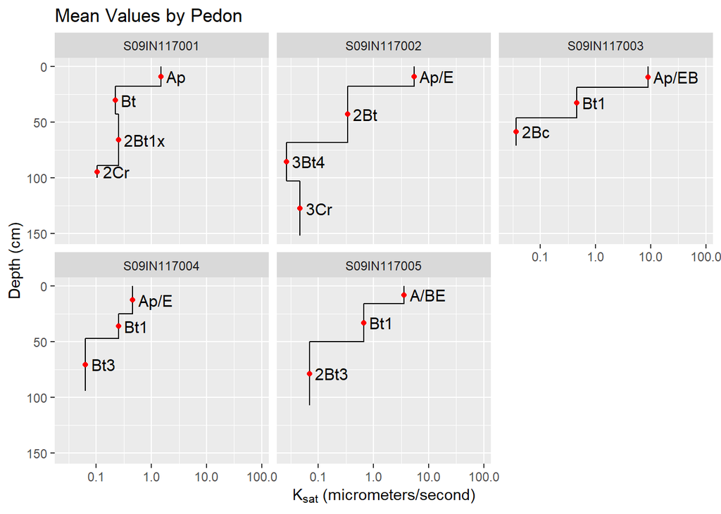

### SSURGO Ksat

Ksat data from SSURGO indicates little variability at the surface, and greater variability at the bottoms of the soil profiles.

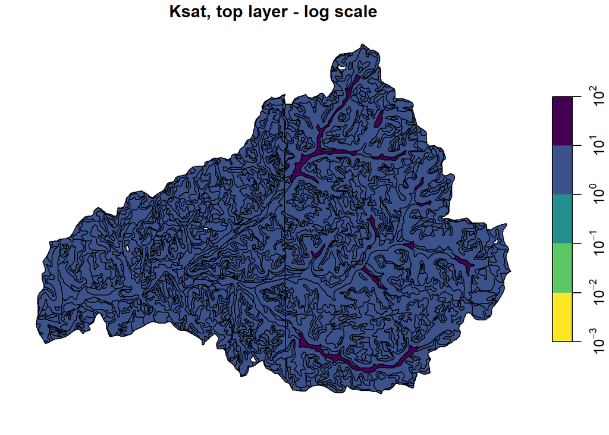

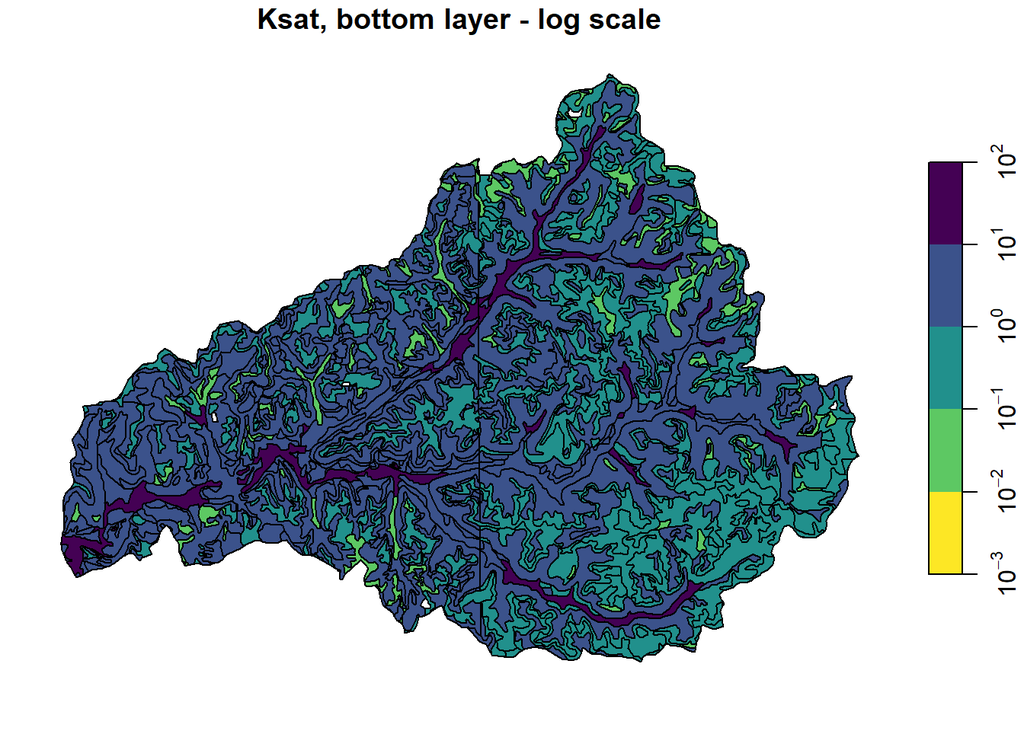

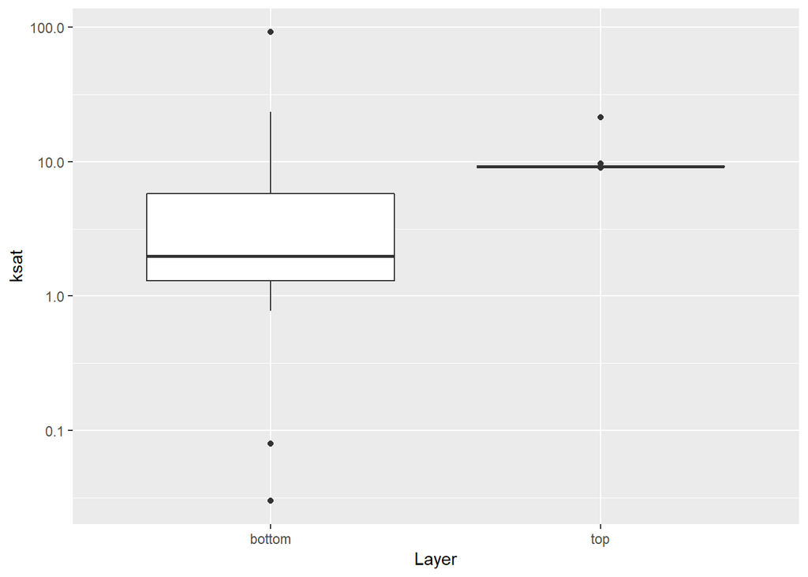

```
##  nationalmusym        surf_ksat         layer                ksat
##  Length:72          Min.   : 9.010   Length:72          Min.   : 0.030
##  Class :character   1st Qu.: 9.170   Class :character   1st Qu.: 2.147
##  Mode  :character   Median : 9.170   Mode  :character   Median : 9.170
##                     Mean   : 9.529                      Mean   : 8.127
##                     3rd Qu.: 9.170                      3rd Qu.: 9.170
##                     Max.   :21.380                      Max.   :91.740
##                     NA's   :36
##     bot_ksat
##  Min.   : 0.030
##  1st Qu.: 1.300
##  Median : 1.995
##  Mean   : 6.726
##  3rd Qu.: 5.973
##  Max.   :91.740
##  NA's   :36
```

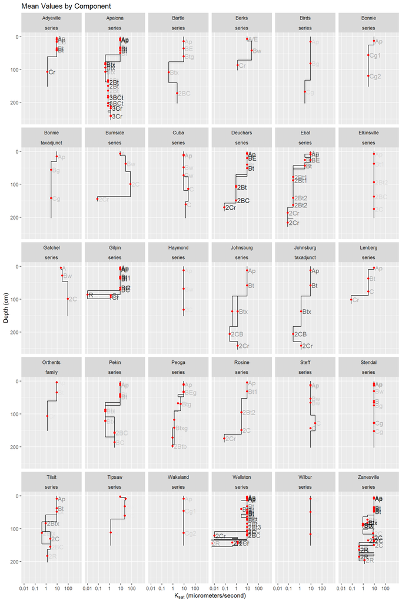

# Hall Creek Watershed Subset

### SSURGO Ksat

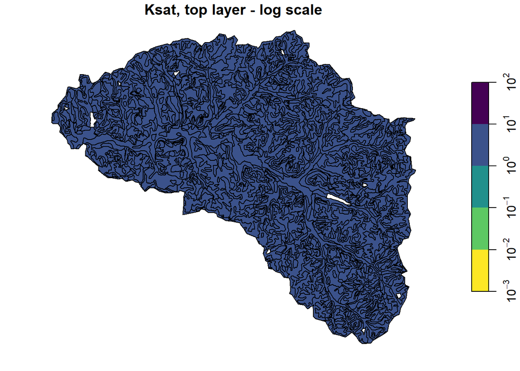

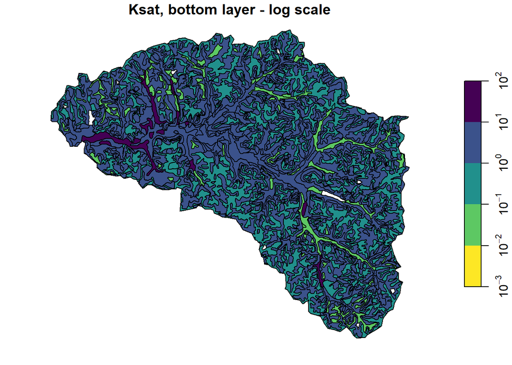

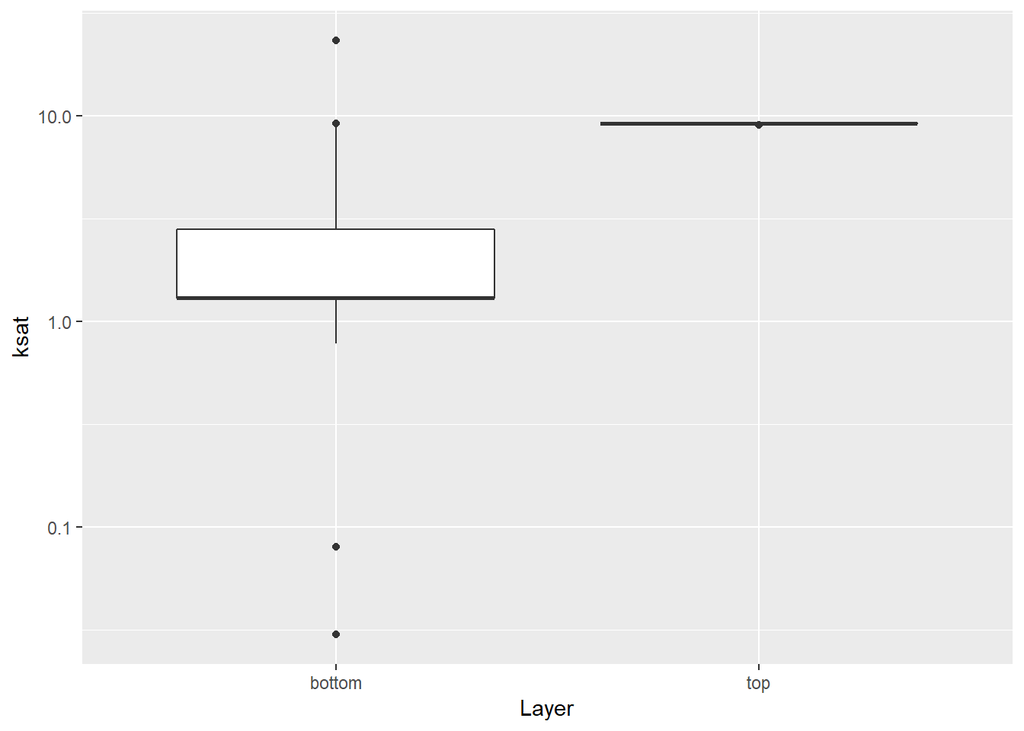

```
##  nationalmusym        surf_ksat        layer                ksat
##  Length:42          Min.   :9.010   Length:42          Min.   : 0.030
##  Class :character   1st Qu.:9.170   Class :character   1st Qu.: 1.300
##  Mode  :character   Median :9.170   Mode  :character   Median : 9.095
##                     Mean   :9.155                      Mean   : 6.166
##                     3rd Qu.:9.170                      3rd Qu.: 9.170
##                     Max.   :9.170                      Max.   :23.290
##                     NA's   :21
##     bot_ksat
##  Min.   : 0.030
##  1st Qu.: 1.300
##  Median : 1.300
##  Mean   : 3.176
##  3rd Qu.: 2.820
##  Max.   :23.290
##  NA's   :21
```

## Modeled Ksat Layers

### Even Scale

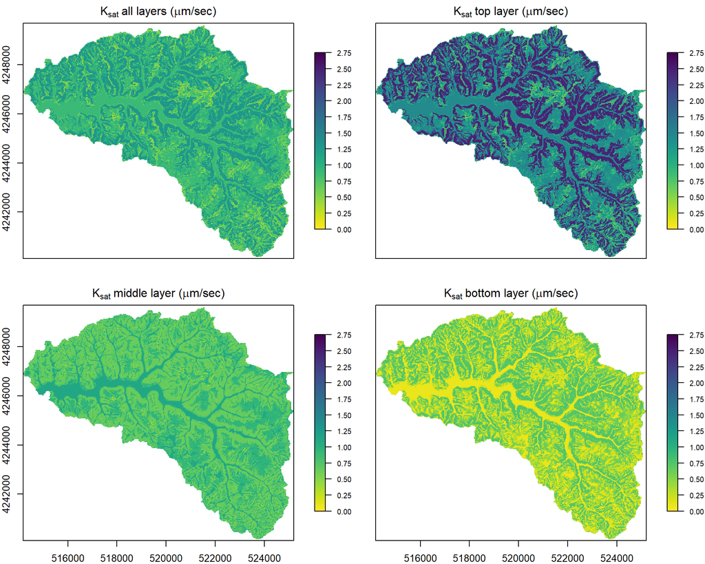

### Ksat Classes

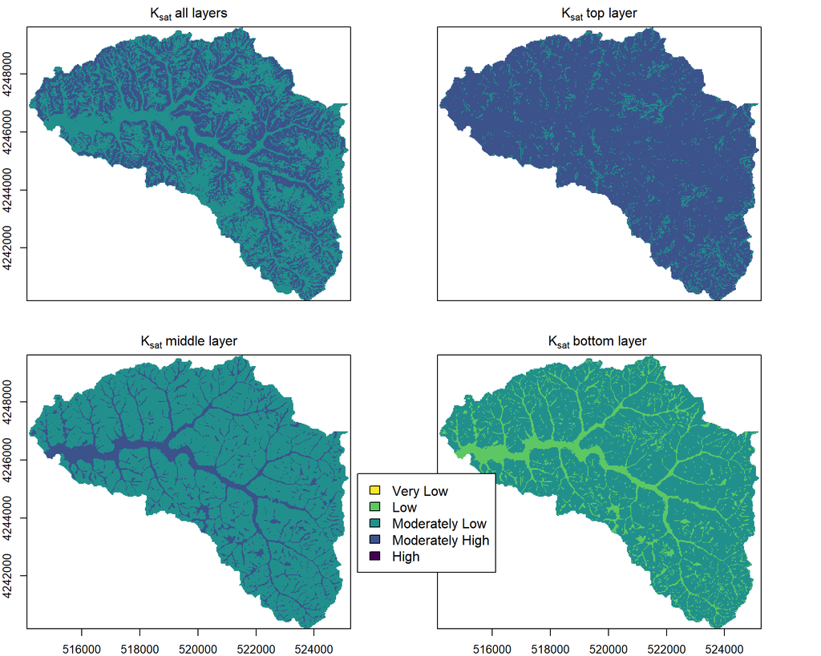

### Boxplots

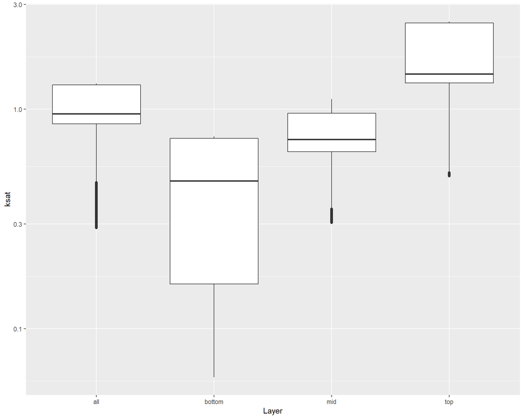

## Quantiles Table

|  | 0% | 25% | 50% | 75% | 100% |
| --- | --- | --- | --- | --- | --- |
| hcr_ksat_l123 | 0.2875897 | 0.8562852 | 0.9513594 | 1.2901643 | 1.3056184 |
| hcr_ksat_l1 | 0.4960591 | 1.3160192 | 1.4445628 | 2.4649277 | 2.5000945 |
| hcr_ksat_l2 | 0.3041549 | 0.6403623 | 0.7281221 | 0.9566626 | 1.1112000 |
| hcr_ksat_l3 | 0.0600298 | 0.1597822 | 0.4708182 | 0.7359588 | 0.7499933 |